# In-brief analysis

Modelling the current COVID-19 Delta-variant outbreak in Sydney

M. Hanly[^1]

T. Churches[^2]

O. Fitzgerald[^3]

CR. MacIntyre[^4]

L. Jorm[^5]

Updated Mon 12 Jul 2021

Abstract

[figure not shown]

# Aim

The aims of this in-brief analysis are to

1. Model observed cases from the current COVID-19 Delta-variant outbreak in Sydney, New South Wales (NSW) using a SEIR epidemic model incorporating dynamic non-pharmaceutical interventions (NPIs).
2. Project the course of the epidemic over the next six weeks under different assumptions regarding ongoing NPIs.

# Methods

## Observed data

Daily incidence data on the current Delta-variant outbreak in New South Wales are taken from https://www.covid19data.com.au/nsw. We exclude cases that were acquired overseas or from interstate travel and include cases with a known or unknown local source as well as those under investigation.

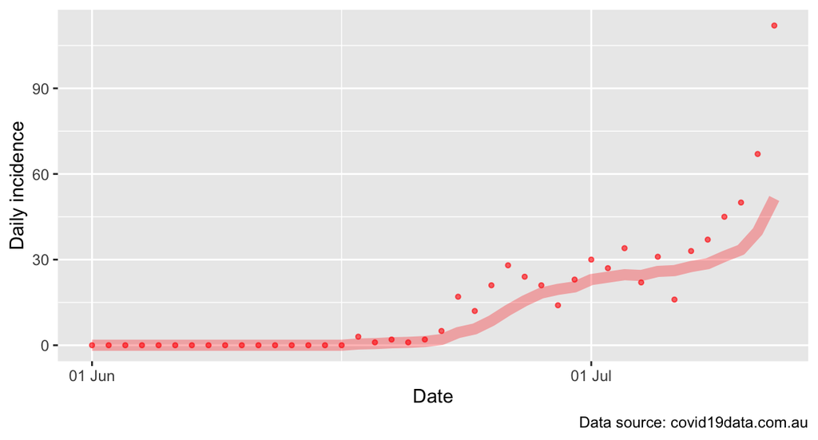

COVID-19 local transmitted cases (New South Wales, June-July 2021)

## Model

We model the outbreak using an age-structured deterministic Susceptible-Exposed-Infected-Recovered (SEIR) model that accounts for dynamic non-pharmaceutical interventions (NPIs). This extended SEIR model has been implemented in our `COVOID` R package, described in detail at [cbdrh.github.io/covoidance](https://cbdrh.github.io/covoidance/). In brief, this model can incorporate two types of NPIs into a standard SEIR epidemic model:

1. interventions that target the average number of daily contacts between individuals from different age groups, which emulates restrictions on social activity such as stay-at home orders.
2. interventions that target the probability of transmission, emulating mask wearing, hand washing, contact tracing and case isolation.

### Demographics

We assumed a population of 4 million unvaccinated individuals with an age distribution reflecting that of the broader Australian population. Given the relatively low proportion of fully vaccinated individuals to date, and the relatively short time frame in question, the potential role of vaccination to mitigate the current outbreak is negligible. To be conservative, we model a population around 80% the size of Sydney assuming the remaining approximately 20% are fully protected.

### Timeline of the outbreak

We assume the following key dates in the timeline of the current outbreak:

**June 1** A hypothetical case zero of the current outbreak, an individual aged 25-30, is first exposed;

**June 16** A man in his 60s working as a driver transporting international flight crew [tests positive for COVID-19](https://www.health.nsw.gov.au/news/Pages/20210616_01.aspx), prompting urgent contact tracing and isolation of close contacts;

**June 25** Lockdowns are introduced to four Sydney Local Government Areas, soon after extended to the greater Sydney region;

**July 16** Date at which current lockdown ends, pending further decisions.

### Code

The R code to replicate this analysis is available on [GitHub](https://github.com/CBDRH/BondiClusterRescue).

# Calibration

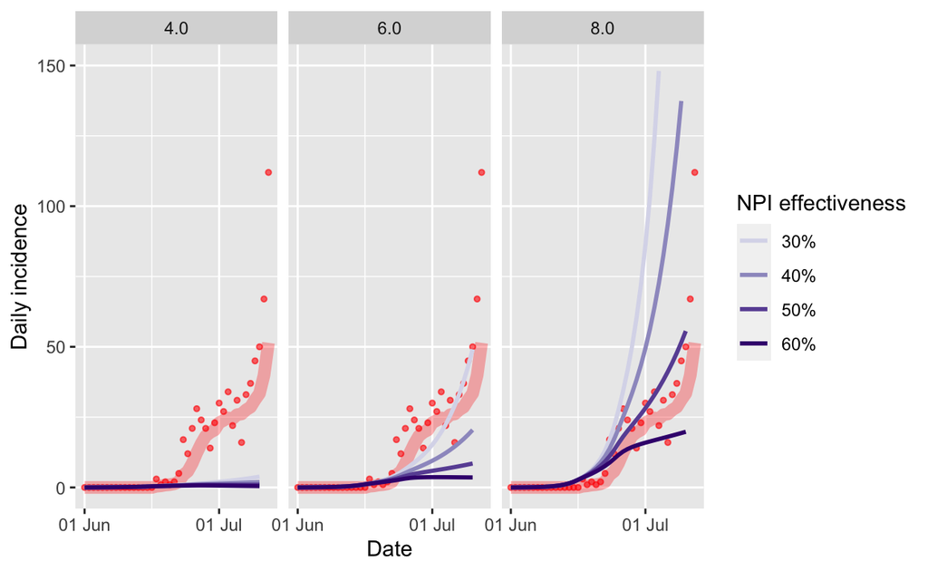

Calibrating the SEIR model to locally transmitted cases in NSW since June 1

*The points shows locally-transmitted cases of COVID-19 in NSW since June 1 2021. The red line shows the seven-day rolling average for the previous seven days. Infections acquired overseas or interstate are excluded.*

Several combinations of R<sub>0</sub> and NPI effectiveness provide a reasonable fit to the data. For our main analysis we choose values of R<sub>0</sub> = 8.0 and NPI effectiveness = 50%. We also undertook an sensitivity analysis using the values of R<sub>0</sub> = 6.0 and NPI effectiveness = 30%.

This range of estimates of R<sub>0</sub> is consistent with the [range of 5 to 8 estimated for the Delta variant by modellers at Imperial College London](https://www.bbc.com/news/health-57431420).

# Intervention scenarios

Our analysis assumes that the current level of restrictions remains in place until Friday 16 July. Thereafter, we projected the model under the following five scenarios.

1. Lift all restrictions on social contacts, with restrictions targeting transmission probability (mask wearing etc) remaining as they are.
2. Relax restrictions on social contacts but tighten restrictions targeting transmission probability
3. Continue with restrictions at the current level
4. Tighten restrictions on social contacts, with restrictions targeting transmission probability remaining as they are.
5. Tighten restrictions on social contacts and also tighten restrictions targeting transmission probability.

These five scenarios are summarised below.

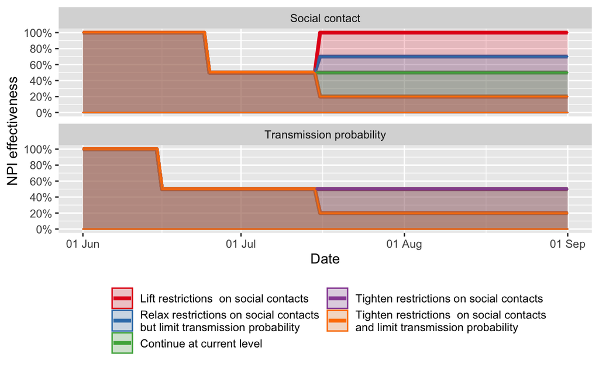

Five scenarios for NPI effectiveness from a baseline of 50% reduction

Note that we assume the restrictions remain in place until September 1.

# Model results

The figure below shows the projected incidence based on R<sub>0</sub> = 8.0 with intervention settings as described above

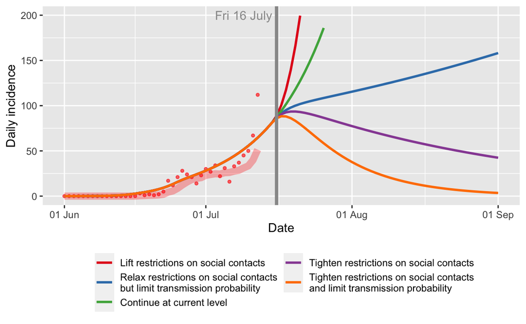

Observed and projected COVID-19 incidence in NSW (1 June - 1 September 2021)

*R<sub>0</sub> = 8.0 and baseline NPI effectiveness = 50%*

The results suggest that completely lifting restrictions on social contact (that is, ending the “lockdown”) would result in an epidemic rise in cases. Continuing with social contact restrictions at the level they were at in early July is unlikely to be sufficient to get the outbreak under control. To reduce daily incidence to a manageable level before September will require a lockdown throughout August where the net effect of all restrictions is stronger than the level observed in early July (that is, currrently).

# Sensitivity analysis

In order to test the robustness of our conclusions to our heuristic choice of R<sub>0</sub> and NPI effectiveness, we repeat the analysis using the alternative specification of R<sub>0</sub> = 6.0 and NPI effectiveness = 30%. We specify a similar set of five future intervention scenarios starting from the baseline of 30%.

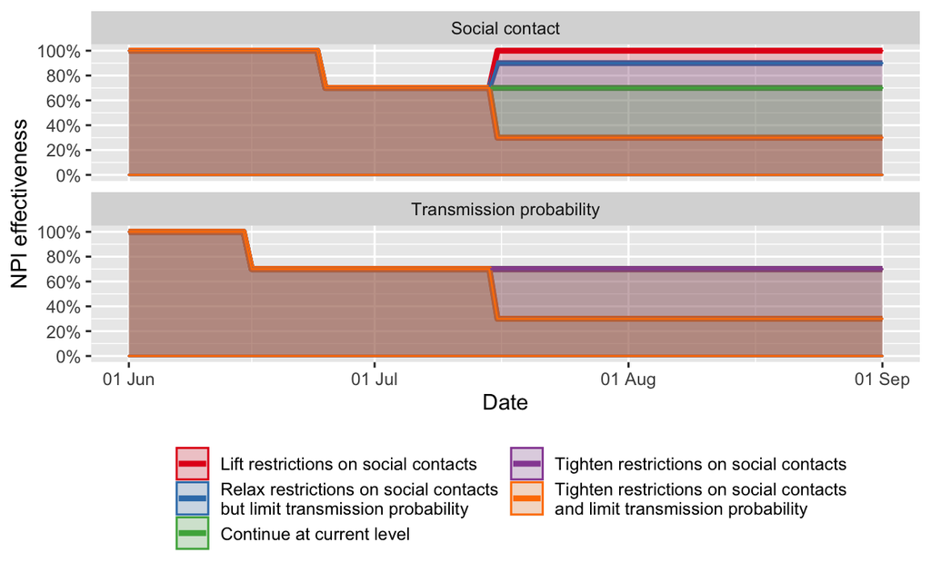

Sensitivity analysis: Five scenarios for NPI effectiveness from a baseline of 30% reduction

The figure below presents the projected case incidence based on this parameterisation.

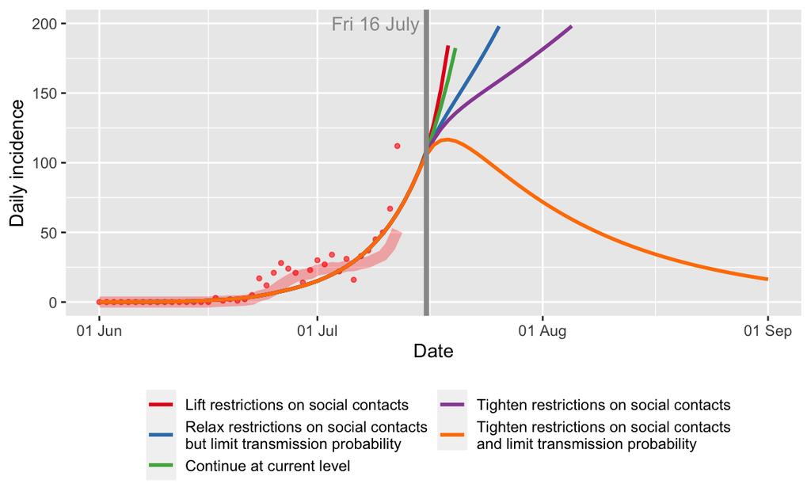

Sensitivity analysis: Observed and projected COVID-19 incidence in NSW (1 June - 1 September 2021)

*R<sub>0</sub> = 6.0 and baseline NPI effectiveness = 30%*

Under this model parameterisation, the main conclusion remains consistent: suppressing the current outbreak will require a lockdown throughout August where the net effect of all interventions exceeds the levels in early July.

# Limitations

There is a large degree of uncertainty around the parameter specification for the SEIR model. This large parameter space makes it easy to fit the model to observed cases, but risks over-fitting which could result in low external validity. This limitation is somewhat assuaged by the observation that our main conclusion was robust to different specifications of R<sub>0</sub> and NPI effectiveness.

# Conclusion

Suppressing the current COVID-19 Delta-variant outbreak in Sydney will require restrictions to remain in place throughout August at a level such that the net effect of all restrictions exceeds that observed in early July. Given the current trajectory, continuing with restrictions at the level observed in late June - early July is unlikely to get the outbreak under control. Lifting the restrictions on social contacts will likely to lead to an exponential rise in infections, and necessitate a longer and more restrictive lockdown within a matter of weeks.

[^1]: Centre for Big Data Research in Health, UNSW Sydney
[^2]: South Western Sydney Clinical School, UNSW Sydney | Ingham Institute for Applied Medical Research
[^3]: Centre for Big Data Research in Health, UNSW Sydney
[^4]: Biosecurity Research Program, The Kirby Institute, UNSW Sydney
[^5]: Centre for Big Data Research in Health, UNSW Sydney